# Chicago Crimes Analysis.

Content ID - Unique identifier for the record.

Case Number - The Chicago Police Department RD Number (Records Division Number), which is unique to the incident.

Date - Date when the incident occurred. this is sometimes a best estimate.

Block - The partially redacted address where the incident occurred, placing it on the same block as the actual address.

IUCR - The Illinois Unifrom Crime Reporting code. This is directly linked to the Primary Type and Description. See the list of IUCR codes at https://data.cityofchicago.org/d/c7ck-438e.

Primary Type - The primary description of the IUCR code.

Description - The secondary description of the IUCR code, a subcategory of the primary description.

Location Description - Description of the location where the incident occurred.

Arrest - Indicates whether an arrest was made.

Domestic - Indicates whether the incident was domestic-related as defined by the Illinois Domestic Violence Act.

Beat - Indicates the beat where the incident occurred. A beat is the smallest police geographic area – each beat has a dedicated police beat car. Three to five beats make up a police sector, and three sectors make up a police district. The Chicago Police Department has 22 police districts. See the beats at https://data.cityofchicago.org/d/aerh-rz74.

District - Indicates the police district where the incident occurred. See the districts at https://data.cityofchicago.org/d/fthy-xz3r.

Ward - The ward (City Council district) where the incident occurred. See the wards at https://data.cityofchicago.org/d/sp34-6z76.

Community Area - Indicates the community area where the incident occurred. Chicago has 77 community areas. See the community areas at https://data.cityofchicago.org/d/cauq-8yn6.

FBI Code - Indicates the crime classification as outlined in the FBI’s National Incident-Based Reporting System (NIBRS). See the Chicago Police Department listing of these classifications at http://gis.chicagopolice.org/clearmap_crime_sums/crime_types.html.

X Coordinate - The x coordinate of the location where the incident occurred in State Plane Illinois East NAD 1983 projection. This location is shifted from the actual location for partial redaction but falls on the same block.

Y Coordinate - The y coordinate of the location where the incident occurred in State Plane Illinois East NAD 1983 projection. This location is shifted from the actual location for partial redaction but falls on the same block.

Year - Year the incident occurred.

Updated On - Date and time the record was last updated.

Latitude - The latitude of the location where the incident occurred. This location is shifted from the actual location for partial redaction but falls on the same block.

Longitude - The longitude of the location where the incident occurred. This location is shifted from the actual location for partial redaction but falls on the same block.

Location - The location where the incident occurred in a format that allows for creation of maps and other geographic operations on this data portal. This location is shifted from the actual location for partial redaction but falls on the same block.

```
|--------------------------------------------------|
|==================================================|
```

The structure of the data…

```
Observations: 6,817,741
Variables: 22
$ id                   <int> 8464728, 8464730, 8464731, 8464732, 8464733, 8464735, 8464736, 8464737, 8464738, 8464739, 8464740, 8464741, 8…
$ case_number          <chr> "HV141356", "HV141566", "HV141577", "HV141414", "HV141527", "HV141452", "HV141417", "HV141592", "HV141568", "…
$ date                 <chr> "02/01/2012 08:00:00 AM", "01/31/2012 06:30:00 PM", "02/01/2012 07:00:00 PM", "02/01/2012 05:00:00 PM", "02/0…
$ block                <chr> "061XX S ABERDEEN ST", "006XX N LAWNDALE AVE", "001XX E 70TH ST", "066XX S KEATING AVE", "008XX S WELLS ST", …
$ iucr                 <chr> "0890", "0810", "2028", "0486", "2027", "0843", "0557", "0460", "0610", "0560", "0460", "0890", "0320", "1120…
$ primary_type         <chr> "THEFT", "THEFT", "NARCOTICS", "BATTERY", "NARCOTICS", "THEFT", "ASSAULT", "BATTERY", "BURGLARY", "ASSAULT", …
$ description          <chr> "FROM BUILDING", "OVER $500", "POSS: SYNTHETIC DRUGS", "DOMESTIC BATTERY SIMPLE", "POSS: CRACK", "ATTEMPT FIN…
$ location_description <chr> "RESIDENCE PORCH/HALLWAY", "SCHOOL, PUBLIC, GROUNDS", "STREET", "SIDEWALK", "APARTMENT", "RESIDENCE", "SIDEWA…
$ arrest               <lgl> FALSE, FALSE, TRUE, FALSE, TRUE, FALSE, TRUE, FALSE, FALSE, FALSE, FALSE, FALSE, FALSE, FALSE, TRUE, TRUE, FA…
$ domestic             <lgl> FALSE, FALSE, FALSE, TRUE, FALSE, FALSE, FALSE, FALSE, FALSE, FALSE, FALSE, FALSE, FALSE, FALSE, FALSE, FALSE…
$ beat                 <int> 712, 1122, 322, 833, 131, 2331, 712, 914, 912, 925, 923, 2024, 1021, 1012, 1431, 1833, 1422, 1411, 2024, 1833…
$ district             <int> 7, 11, 3, 8, 1, 19, 7, 9, 9, 9, 9, 20, 10, 10, 14, 18, 14, 14, 20, 18, 20, 15, 11, 3, 12, 6, 17, 8, 8, 8, 7, …
$ ward                 <int> 16, 27, 6, 13, 2, 44, 16, 12, 12, 11, 11, 46, 24, 24, 1, 42, 35, 33, 46, 42, 40, 37, 2, 5, 27, 6, 33, 15, 14,…
$ community_area       <int> 68, 23, 69, 64, 32, 6, 68, 61, 58, 34, 60, 3, 29, 29, 22, 8, 22, 21, 3, 8, 4, 25, 27, 43, 24, 44, 14, 66, 63,…
$ fbi_code             <chr> "06", "06", "18", "08B", "18", "06", "04A", "08B", "05", "08A", "08B", "06", "03", "10", "26", "06", "04A", "…
$ x_coordinate         <int> 1170035, 1151604, 1178551, 1145859, 1174838, 1172655, 1169947, 1163776, 1158151, 1174889, 1168945, 1168754, 1…
$ y_coordinate         <int> 1864052, 1904073, 1858640, 1860098, 1896647, 1922913, 1867308, 1873927, 1873694, 1880674, 1886863, 1932564, 1…
$ year                 <int> 2012, 2012, 2012, 2012, 2012, 2012, 2012, 2012, 2012, 2012, 2012, 2012, 2012, 2011, 2012, 2012, 2012, 2012, 2…
$ updated_on           <chr> "02/10/2018 03:50:01 PM", "02/10/2018 03:50:01 PM", "02/10/2018 03:50:01 PM", "02/10/2018 03:50:01 PM", "02/1…
$ latitude             <dbl> 41.78245, 41.89266, 41.76741, 41.77209, 41.87179, 41.94391, 41.79139, 41.80968, 41.80916, 41.82796, 41.84507,…
$ longitude            <dbl> -87.65215, -87.71867, -87.62109, -87.74088, -87.63356, -87.64080, -87.65237, -87.67482, -87.69545, -87.63385,…
$ location             <chr> "(41.782451884, -87.652146777)", "(41.892655438, -87.718670666)", "(41.767411423, -87.6210892)", "(41.7720928…
```

How many columns have NA values…

```
                  id          case_number                 date                block                 iucr         primary_type
                   0                    0                    0                    0                    0                    0
         description location_description               arrest             domestic                 beat             district
                   0                    0                    0                    0                    0                   47
                ward       community_area             fbi_code         x_coordinate         y_coordinate                 year
              614853               613530                    0                62668                62668                    0
          updated_on             latitude            longitude             location
                   0                62668                62668                    0
1.963 sec elapsed
```

Lets see the count of unique values per columns

```
                  id          case_number                 date                block                 iucr         primary_type
             6817741              6817333              2733746                60106                  403                   35
         description location_description               arrest             domestic                 beat             district
                 381                  180                    2                    2                  304                   25
                ward       community_area             fbi_code         x_coordinate         y_coordinate                 year
                  51                   79                   26                78575               129819                   19
          updated_on             latitude            longitude             location
                2627               861180               860630               862360
8.566 sec elapsed
```

Lets check the trend of crimes across the data…

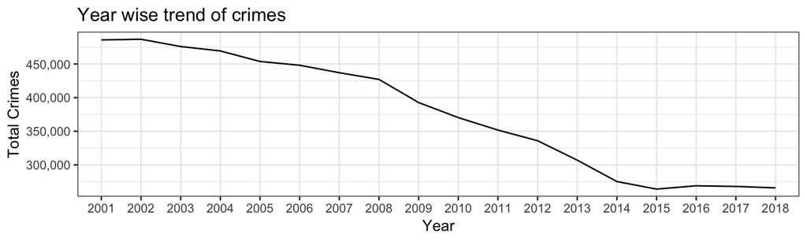

Which are the primary crimes in the data…

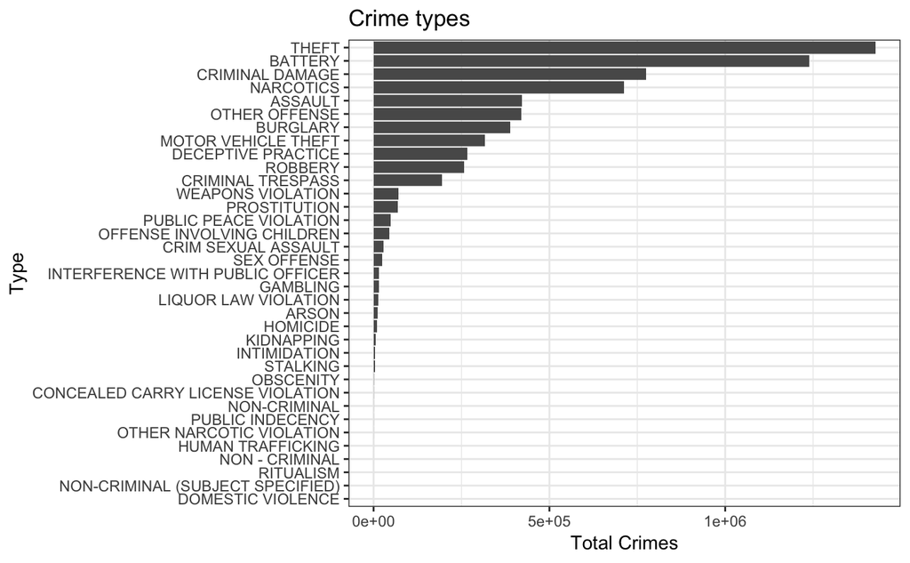

What is the frequency of arrests in the data…

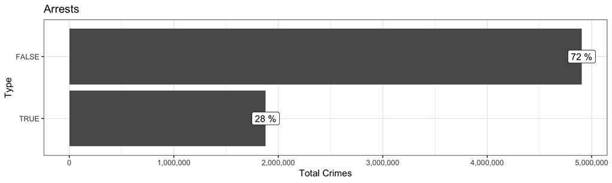

Any trends to the arrest category per year

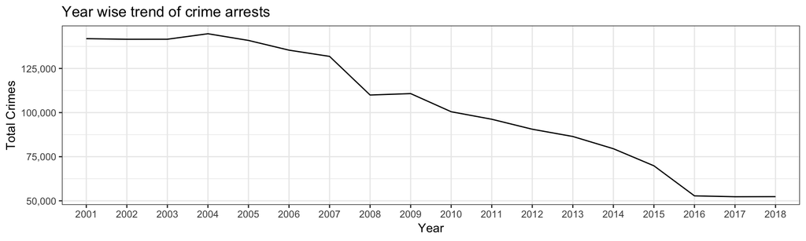

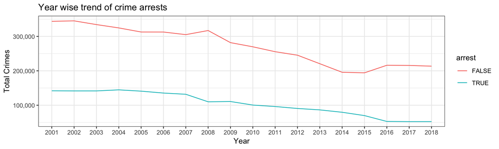

Lets check on various FBI codes…

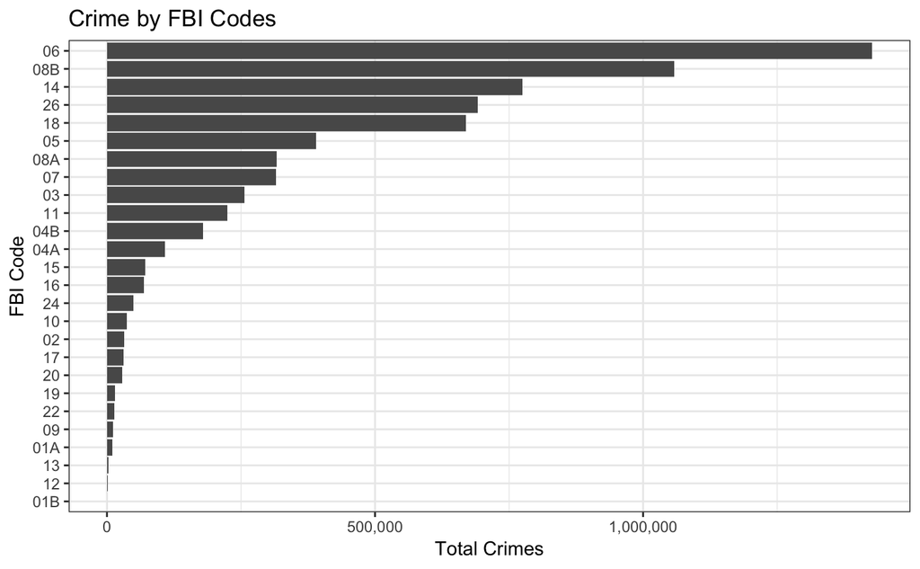

ROUGH WORK